# Monaco Experiment Models

Subset the dataset to include only the relevant temperature targets (20 °C and 24 °C). Ensure the data is formatted correctly for statistical analysis.

```r
temp_case_for_stat<-subset(temp_case_full, T_targeted==20|T_targeted==24)
temp_case_for_stat$Treatment<-as.factor(temp_case_for_stat$Treatment)
# Ensure GR is numeric
temp_case_for_stat$GR <- as.numeric(temp_case_for_stat$GR)

# Subset data by Li_targeted levels
temp_case_for_stat_20<- subset(temp_case_for_stat, T_targeted == 20)
temp_case_for_stat_24 <- subset(temp_case_for_stat, T_targeted == 24)

# Shapiro-Wilk Test
shapiro_results <- temp_case_for_stat %>%
  group_by(Treatment) %>%
  summarise(shapiro_p_value = shapiro.test(GR)$p.value)

cat("\nShapiro-Wilk Test Results:\n")
```

```
##
## Shapiro-Wilk Test Results:
```

```r
print(as.data.frame(shapiro_results))  # Convert tibble to data frame
```

```
##      Treatment shapiro_p_value
## 1  ML1P1_20_R1       0.2574815
## 2  ML1P1_20_R2       0.7926540
## 3  ML1P1_24_R1       0.3203047
## 4  ML1P1_24_R2       0.4595453
## 5  ML1P2_20_R1       0.9498778
## 6  ML1P2_20_R2       0.6631284
## 7  ML1P2_24_R1       0.6909674
## 8  ML1P2_24_R2       0.9254671
## 9  ML2P1_20_R1       0.3933359
## 10 ML2P1_20_R2       0.4900002
## 11 ML2P1_24_R1       0.6498643
## 12 ML2P1_24_R2       0.3040053
## 13 ML2P2_20_R1       0.7456292
## 14 ML2P2_20_R2       0.2634574
## 15 ML2P2_24_R1       0.7517508
## 16 ML2P2_24_R2       0.2377252
## 17          T3       0.4949512
## 18          T4       0.5614837
```

```r
# Levene's Test
levene_test_20 <- leveneTest(GR ~ Stressors, data = temp_case_for_stat_20)
levene_test_24 <- leveneTest(GR ~ Stressors, data = temp_case_for_stat_24)

levene_results_table <- data.frame(
  Group = c("T targeted: 20 °C", "T targeted: 24 °C"),
  F_value = c(levene_test_20$`F value`[1], levene_test_24$`F value`[1]),
  P_value = c(levene_test_20$`Pr(>F)`[1], levene_test_24$`Pr(>F)`[1])
)


cat("\nLevene's Test Results:\n")
```

```
##
## Levene's Test Results:
```

```r
print(levene_results_table)
```

```
##               Group     F_value      P_value
## 1 T targeted: 20 °C 15.10260225 0.0002105877
## 2 T targeted: 24 °C  0.05728939 0.8113429015
```

```r
# Wilcoxon rank-sum tests
temp_case_for_stat_20_s<-subset(temp_case_for_stat_20, Stressors=="Single")
temp_case_for_stat_20_m<-subset(temp_case_for_stat_20, Stressors=="Multiple")

temp_case_for_stat_24_s<-subset(temp_case_for_stat_24, Stressors=="Single")
temp_case_for_stat_24_m<-subset(temp_case_for_stat_24, Stressors=="Multiple")

wilk_20<-wilcox.test(temp_case_for_stat_20_s$GR,temp_case_for_stat_20_m$GR)
wilk_24<-wilcox.test(temp_case_for_stat_24_s$GR,temp_case_for_stat_24_m$GR)


wilk_results_table <- data.frame(
  Group = c("T targeted: 20 °C", "T targeted: 24 °C"),
  W_value = c(wilk_20$statistic, wilk_24$statistic),
  P_value = c(wilk_20$p.value, wilk_24$p.value)
)

cat("\nWilcoxon Rank-Sum Test Results:\n")
```

```
##
## Wilcoxon Rank-Sum Test Results:
```

```r
print(wilk_results_table)
```

```
##               Group W_value     P_value
## 1 T targeted: 20 °C     786 0.001635909
## 2 T targeted: 24 °C     444 0.967234434
```

```r
# ANOVA

anova_20<-aov(GR~Stressors, data=temp_case_for_stat_20)
anova_24<-aov(GR~Stressors, data=temp_case_for_stat_24)
s_anova_20<-summary(anova_20)
s_anova_24<-summary(anova_24)

anova_results_table <- data.frame(
  Group = c("T targeted: 20 °C", "T targeted: 24 °C"),
  F_value = c(summary(anova_20)[[1]]$`F value`[1], summary(anova_20)[[1]]$`F value`[1]),
  P_value = c(summary(anova_24)[[1]]$`Pr(>F)`[1], summary(anova_24)[[1]]$`Pr(>F)`[1])
)

cat("\nANOVA Results:\n")
```

```
##
## ANOVA Results:
```

```r
print(anova_results_table)
```

```
##               Group  F_value   P_value
## 1 T targeted: 20 °C 11.65983 0.9293628
## 2 T targeted: 24 °C 11.65983 0.9293628
```

*Shapiro-Wilk Test:* The growth rate data is normally distributed in all groups.

*Levene’s Test:* Confirms homogeneity of variances across single and multiple stressor experiments under conditions of 20=4 °C, and rejects for 20 °C.

*Wilcoxon Rank-Sum Test:* Highlights differences in median growth rates when the experiment is set on 20 °C, and no difference where experiment is set on 24 °C.

*ANOVA:* Can be ignored.

*Visualization of statistical results*

Create a boxplot to compare growth rates between single and multiple stressor conditions, grouped by temperature targets (20 °C and 24 °C). Use facets to separate groups for easier interpretation.

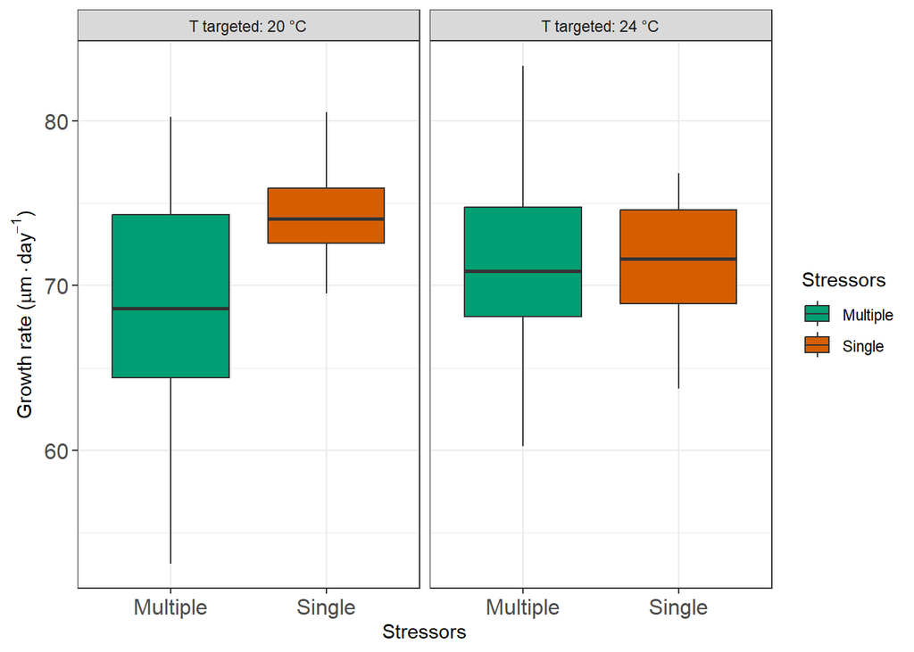

```r
temp_case_for_stat$temp_targeted_label <- factor(
  temp_case_for_stat$T_targeted,
  levels = c(20, 24),
  labels = c("T targeted: 20 °C", "T targeted: 24 °C")
)

p1 <- ggplot(temp_case_for_stat, aes(x = Stressors, y = GR, fill = Stressors)) +
  geom_boxplot() +
  facet_grid(~temp_targeted_label) +
  labs(
    x = "Stressors",
    y = expression(paste("Growth rate ("*mu*"m"%.%"day"^-1*")"))
  ) +
  theme_bw() +
  theme(axis.text = element_text(size = 12)) +
  scale_fill_manual(name = "Stressors",
                    values = c("Single" = "#D55E00", "Multiple" = "#009E73"))

p1
```

**pH case exploration**

Prepare the dataset by combining pH-specific data from single and multiple stressor experiments. Add a column to indicate whether the data comes from single or multiple stressor conditions.

```r
pH_case<-pH_only[,1:4]
MS_pH_only<-full_multiple[,c(1,7,8,4)]
names(pH_case)<-c("Treatment" ,"pH_targeted", "pH_measured","GR")
names(MS_pH_only)<-c("Treatment" ,"pH_targeted", "pH_measured","GR")
MS_pH_only$Stressors<-rep("Multiple",nrow(MS_pH_only))
pH_case$Stressors<-rep("Single",nrow(pH_case))
pH_case_full<-rbind(pH_case,MS_pH_only)
```

*Visualization of growth rates by pH*

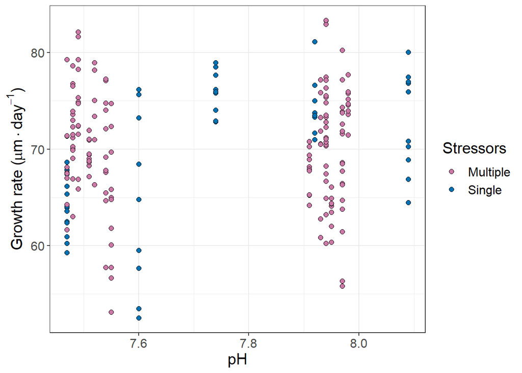

```r
p <- ggplot() +
  geom_point(data = pH_case_full,
             aes(y = GR, x = pH_measured, fill = Stressors),
             shape = 21,
             size = 2) +
  xlab("pH") +
  ylab(expression(paste("Growth rate ("*mu*"m"%.%"day"^-1*")"))) +
  theme_bw() +
  theme(text = element_text(size = 15)) +
  scale_fill_manual(name = "Stressors",
                    values = c("Single" = "#0072B2", "Multiple" = "#CC79A7"))

p
```

*Statistical tests for pH-dependent data*

Subset the data set to include only the relevant pH target levels (7.7 and 8.1). Ensure the data is formatted correctly for statistical analysis.

```r
pH_case_for_stat<-subset(pH_case_full, pH_targeted==7.7|pH_targeted==8.1)
pH_case_for_stat$Treatment<-as.factor(pH_case_for_stat$Treatment)
# Ensure GR is numeric
pH_case_for_stat$GR <- as.numeric(pH_case_for_stat$GR)

# Subset data by Li_targeted levels
pH_case_for_stat_77<- subset(pH_case_for_stat, pH_targeted == 7.7)
pH_case_for_stat_81 <- subset(pH_case_for_stat, pH_targeted == 8.1)

# Shapiro-Wilk Test
shapiro_results <- pH_case_for_stat %>%
  group_by(Treatment) %>%
  summarise(shapiro_p_value = shapiro.test(GR)$p.value)

cat("\nShapiro-Wilk Test Results:\n")
```

```
##
## Shapiro-Wilk Test Results:
```

```r
print(as.data.frame(shapiro_results))  # Convert tibble to data frame
```

```
##      Treatment shapiro_p_value
## 1  ML1P1_20_R1       0.2574815
## 2  ML1P1_20_R2       0.7926540
## 3  ML1P1_24_R1       0.3203047
## 4  ML1P1_24_R2       0.4595453
## 5  ML1P2_20_R1       0.9498778
## 6  ML1P2_20_R2       0.6631284
## 7  ML1P2_24_R1       0.6909674
## 8  ML1P2_24_R2       0.9254671
## 9  ML2P1_20_R1       0.3933359
## 10 ML2P1_20_R2       0.4900002
## 11 ML2P1_24_R1       0.6498643
## 12 ML2P1_24_R2       0.3040053
## 13 ML2P2_20_R1       0.7456292
## 14 ML2P2_20_R2       0.2634574
## 15 ML2P2_24_R1       0.7517508
## 16 ML2P2_24_R2       0.2377252
## 17          P1       0.2237816
## 18          P3       0.4371088
```

```r
# Levene's Test
levene_test_77 <- leveneTest(GR ~ Stressors, data = pH_case_for_stat_77)
levene_test_81 <- leveneTest(GR ~ Stressors, data = pH_case_for_stat_81)

levene_results_table <- data.frame(
  Group = c("pH targeted: 7.7", "pH targeted: 8.1"),
  F_value = c(levene_test_77$`F value`[1], levene_test_81$`F value`[1]),
  P_value = c(levene_test_77$`Pr(>F)`[1], levene_test_81$`Pr(>F)`[1])
)


cat("\nLevene's Test Results:\n")
```

```
##
## Levene's Test Results:
```

```r
print(levene_results_table)
```

```
##              Group   F_value    P_value
## 1 pH targeted: 7.7 5.0292903 0.02768947
## 2 pH targeted: 8.1 0.2152186 0.64384020
```

```r
# Wilcoxon rank-sum tests
pH_case_for_stat_77_s<-subset(pH_case_for_stat_77, Stressors=="Single")
pH_case_for_stat_77_m<-subset(pH_case_for_stat_77, Stressors=="Multiple")

pH_case_for_stat_81_s<-subset(pH_case_for_stat_81, Stressors=="Single")
pH_case_for_stat_81_m<-subset(pH_case_for_stat_81, Stressors=="Multiple")

wilk_77<-wilcox.test(pH_case_for_stat_77_s$GR,pH_case_for_stat_77_m$GR)
wilk_81<-wilcox.test(pH_case_for_stat_81_s$GR,pH_case_for_stat_81_m$GR)


wilk_results_table <- data.frame(
  Group = c("pH targeted: 7.7", "pH targeted: 8.1"),
  W_value = c(wilk_77$statistic, wilk_81$statistic),
  P_value = c(wilk_77$p.value, wilk_81$p.value)
)

cat("\nWilcoxon Rank-Sum Test Results:\n")
```

```
##
## Wilcoxon Rank-Sum Test Results:
```

```r
print(wilk_results_table)
```

```
##              Group W_value     P_value
## 1 pH targeted: 7.7     537 0.002031778
## 2 pH targeted: 8.1     584 0.080626105
```

```r
# ANOVA

anova_77<-aov(GR~Stressors, data=pH_case_for_stat_77)
anova_81<-aov(GR~Stressors, data=pH_case_for_stat_81)
s_anova_77<-summary(anova_77)
s_anova_81<-summary(anova_81)

anova_results_table <- data.frame(
  Group = c("pH targeted: 7.7", "pH targeted: 8.1"),
  F_value = c(summary(anova_77)[[1]]$`F value`[1], summary(anova_77)[[1]]$`F value`[1]),
  P_value = c(summary(anova_81)[[1]]$`Pr(>F)`[1], summary(anova_81)[[1]]$`Pr(>F)`[1])
)

cat("\nANOVA Results:\n")
```

```
##
## ANOVA Results:
```

```r
print(anova_results_table)
```

```
##              Group  F_value   P_value
## 1 pH targeted: 7.7 8.092082 0.1108638
## 2 pH targeted: 8.1 8.092082 0.1108638
```

*Shapiro-Wilk Test:* Determines if growth rate data is normally distributed in all groups.

*ANOVA:* Can be ignored.

*Visualization of statistical results*

Create a boxplot to compare growth rates between single and multiple stressor conditions, grouped by pH target levels (7.7 and 8.1). Use facets to separate groups for clearer interpretation.

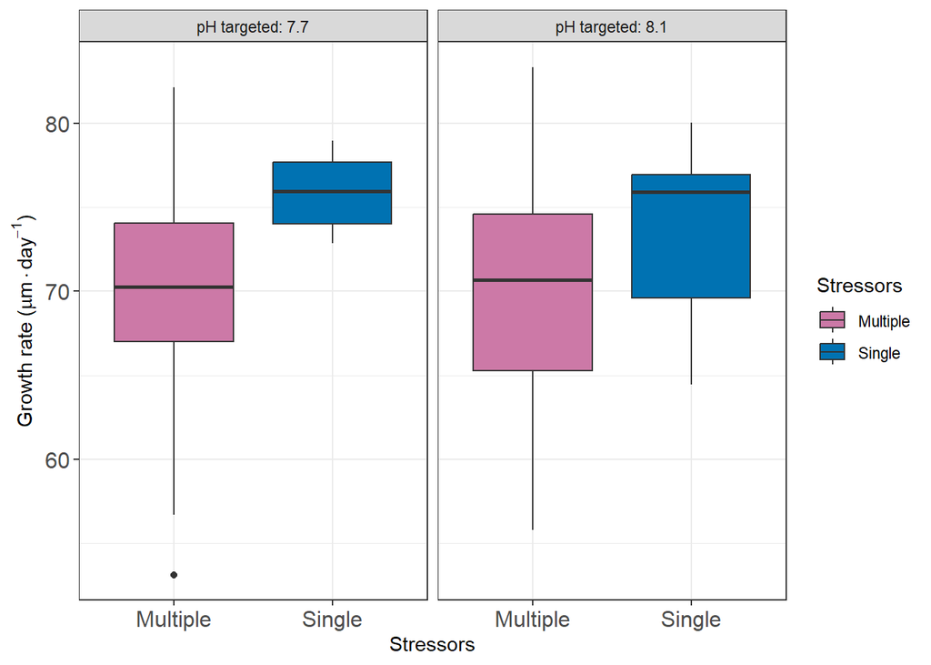

```r
pH_case_for_stat$pH_targeted_label <- factor(
  pH_case_for_stat$pH_targeted,
  levels = c(7.7,8.1),
  labels = c("pH targeted: 7.7", "pH targeted: 8.1")
)

p1 <- ggplot(pH_case_for_stat, aes(x = Stressors, y = GR, fill = Stressors)) +
  geom_boxplot() +
  facet_grid(~pH_targeted_label) +
  labs(
    x = "Stressors",
    y = expression(paste("Growth rate ("*mu*"m"%.%"day"^-1*")"))
  ) +
  theme_bw() +
  theme(axis.text = element_text(size = 12)) +
  scale_fill_manual(name = "Stressors",
                    values = c("Single" = "#0072B2", "Multiple" = "#CC79A7"))

p1
```